# Simulación de procesos AR, MA y ARMA

Universidad Nacional de Colombia - Facultad de Ciencias Económicas

Equipo de Monitores - Econometría II

2023-08-20

# Carga y descarga de paquetes

Aunque en ésta sesión la mayoría de paquetes no se usarán, es necesario irse relacionando con ellos para conocer sus respectivas funciones y su importancia para el manejo de series temporales.

```r
pacman :: p_load(
  forecast,   # Para hacer pronóstico con los modelos ARIMA
  lmtest,     # Obtener la significancia individual de los coeficientes ARIMA
  urca,       # Prueba de raíz unitaria (estacionariedad)
  tseries,    # Para estimar modelos de series de tiempo y pruebas de supuestos
  readxl,     # Para leer archivos de excel
  stargazer,  # Presentación de resultados y tablas más estéticos
  psych,      # Para hacer estadística descriptiva
  seasonal,   # Para desestacionalizar las series de tiempo
  aTSA,       # Para hacer prueba de efectos ARCH
  astsa,      # Para estimar, validar y pronosticar en modelos ARIMA/SARIMA
  xts,        # Para utilizar objetos de tipo xts
  tidyverse,  # Conjunto de paquetes (incluye dplyr y ggplot2)
  readxl,     # Para leer archivo excel
  car         # Función qqplot
)
```

# Comentarios sobre el manejo de series de tiempo y simulaciones en R

En R uno puede trabajar series de tiempo con 3 tipos de objetos:

- 1. ts
- 2. zoo
- 3. xts

Es muy común utilizar objetos ts en el modelamiento de series de tiempo en R. En el presente script, se va a ser usó de ese tipo de objeto para modelar las series de tiempo. No obstante, a la hora de realizar análisis más avanzados de series de tiempo, como podría ser el caso de trabajar con series de tiempo financieras, es indispensable conocer/manejar los paquetes zoo y xts para series de tiempo. Esos dos paquetes los estudiaremos en mayor detalle en futuras monitorias.

## Características importantes de las simulaciónes

Se empleará el comando arima.sim, nativo de R, para simular de manera automática diferentes procesos de series de tiempo univariados (tanto estacionarios como no estacionarios).

La estacionariedad puede ser plausible según un análisis gráfico, donde verificaremos la existencia de única media (constante) a largo plazo y una varianza aparentemente constante a lo largo de la muestra (sin clusters de volatilidad). Aún así, se recomienda acompañar las inferencias gráficas con pruebas formales y análisis de correlogramas, como los que mostraremos a lo largo de esta sesión.

De igual forma, se simulará la innovación (también conocido como el error) del proceso mediante una simulación de una variable aleatoria normal estándar, para poder hacer el análisis estadístico pertinente.

- ¿Qué hacemos si en la práctica no tenemos normalidad en el error?

En la práctica lo normal es encontrarnos con distribuciones que no son normales. En tales situaciones, si se quiere inferencia estadística sobre la serie, va a ser necesario emplear métodos de simulación (como bootstrapping) que permite aproximar mejor la distribución real de los errores (a partir de remuestreos de la muestra). La simulación por bootstrapping la pueden ver ya sea en el libro de series de timepo Enders o en el libro de probabilidad de´ DeGroot.

## Tamaño de muestra

Las propiedades teóricas de los diferentes procesos estacionarios se basan en teoría de grandes muestras (en realidad de tener procesos infinitos). Por tanto, entre más grande el tamaño de muestra, mejor se van a ver los resultados de las simulación. En la práctica, es muy difícil tener muestras tan grandes para series de tiempo (y más aún si se trabaja con series macro de carácter mensual o trimestral), por lo que en la práctica es usual trabajar con series con mucho menos observaciones (e.g. 75 observaciones)

Como hoy trabajaremos con ejemplos simulados, podemos seleccionar el número de observaciones que deseemos. Así que prodeceremos a limpiar el environment y fijar un tamaño de 1000 observaciones

```r
rm(list = ls()) # Limpiar el entorno

obs =  1000 # Fijar 1000 observaciones
```

# 1. Proceso de Ruido Blanco

Recordemos que un proceso de ruido blanco posee una media constante, una varianza constante y no está correlacionado a través del tiempo (Lo que lo hace blanco).

```r
set.seed(1) #Semilla para que todos veamos lo mismo :)

yt_rb = ts(arima.sim(model= list(order = c(0,0,0)), n = obs,
                     innov=rnorm(n = obs, mean = 0, sd = 1)))
```

Grafiquemos el proceso.

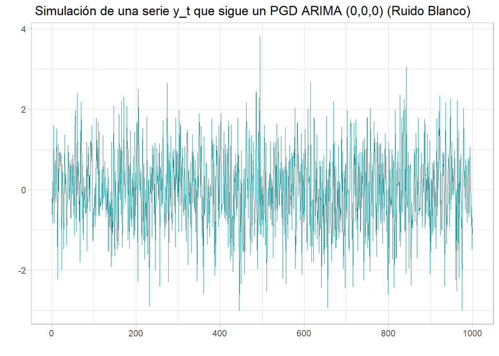

```r
x11()
autoplot(yt_rb, xlab="",ylab="", main=" Simulación de una serie y_t que sigue un PGD ARIMA (0,0,0) (Ruido Blanco)",lty=1, lwd=0.25, col="turquoise4") + theme_light()
```

Podemos visualizar que la serie fluctúa sobre una media constante (media cero en este caso) y “no varía tanto”. Veamos los gráficos FAC y FACP para visualizar que sea un proceso de ruido blanco.

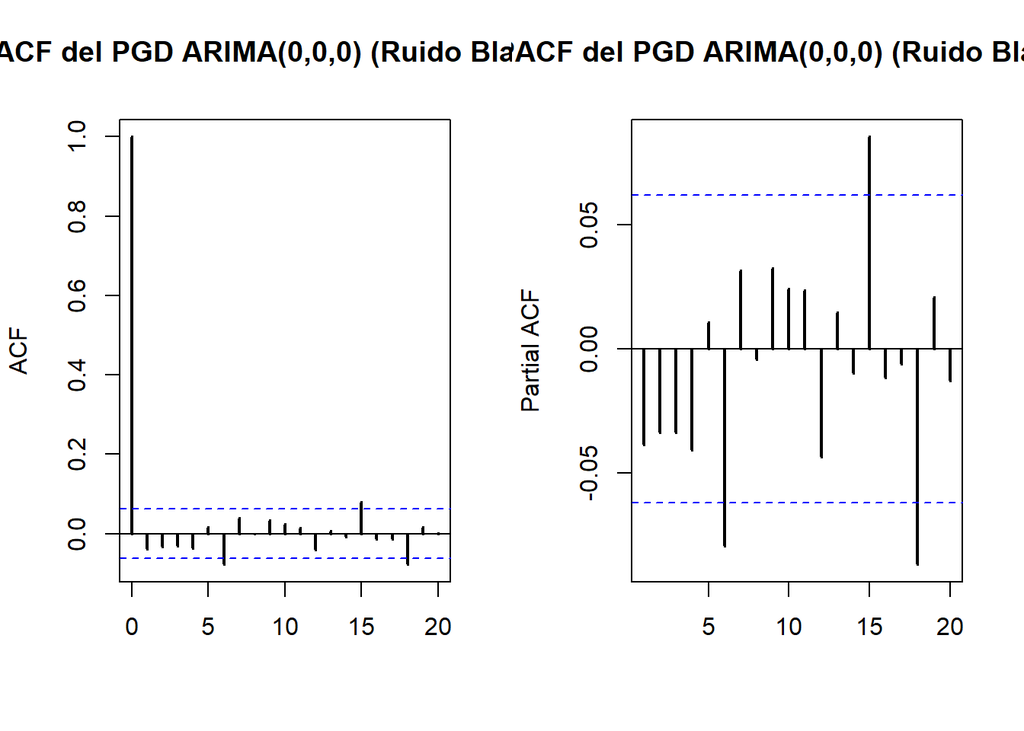

```r
lags=20
x11()
par(mfrow=c(1,2))
acf(yt_rb,lag.max=lags,plot=T,lwd=2,xlab='',main='ACF del PGD ARIMA(0,0,0) (Ruido Blanco)')
pacf(yt_rb,lag.max=lags,plot=T,lwd=2,xlab='',main='PACF del PGD ARIMA(0,0,0) (Ruido Blanco)')
```

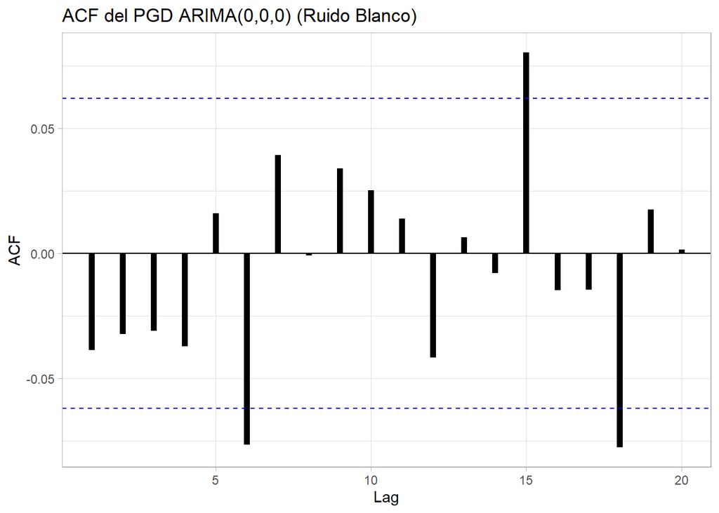

```r
# Versíón ggplot:
x11()
ggAcf(yt_rb,lag.max=lags,plot=T,lwd=2) + ggtitle('ACF del PGD ARIMA(0,0,0) (Ruido Blanco)') + theme_light()
```

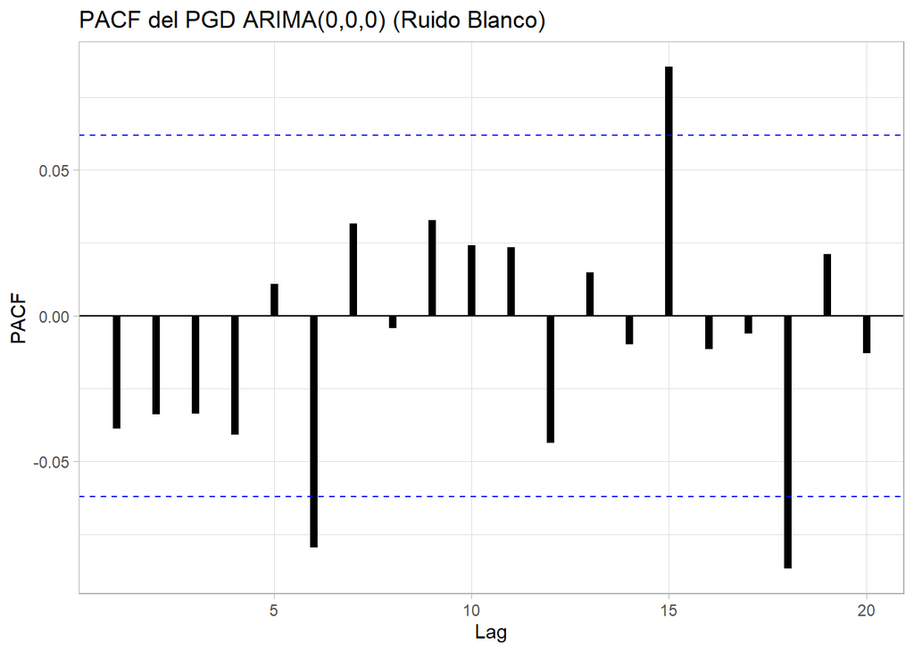

```r
x11()
ggPacf(yt_rb,lag.max=lags,plot=T,lwd=2) + ggtitle('PACF del PGD ARIMA(0,0,0) (Ruido Blanco)') + theme_light()
```

# 2. Proceso AR(1) estacionario

Simulemos un proceso autorregresivo estacionario.

```r
set.seed(8202)

yt1s = ts(arima.sim(model= list(order = c(1,0,0), ar=c(0.6)), n = obs, innov=rnorm(n = obs, mean = 0, sd = 1)))
```

Como es deseable hacer en primera instancia, vamos a graficar el proceso.

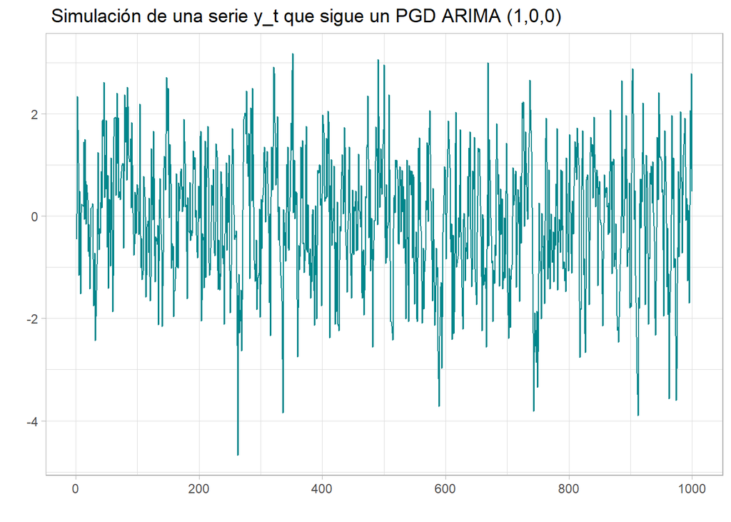

```r
x11()
autoplot(yt1s, xlab="",ylab="", main=" Simulación de una serie y_t que sigue un PGD ARIMA (1,0,0)",lty=1, lwd=0.4, col="turquoise4") + theme_light()
```

Podemos analizar gráficamente sus propiedades como series estacionaria.

Grafiquemos sus FAC y FACP con el siguiente comando.

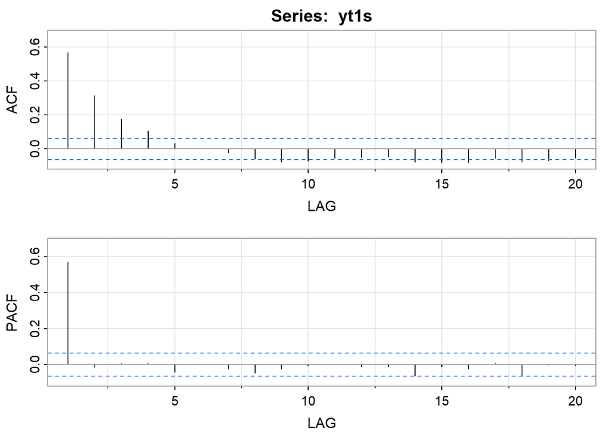

```
##      [,1]  [,2] [,3] [,4]  [,5] [,6]  [,7]  [,8]  [,9] [,10] [,11] [,12] [,13]
## ACF  0.57  0.31 0.18 0.10  0.03    0 -0.02 -0.06 -0.08 -0.07 -0.06 -0.05 -0.05
## PACF 0.57 -0.02 0.01 0.01 -0.04    0 -0.02 -0.05 -0.02 -0.01  0.00 -0.01 -0.01
##      [,14] [,15] [,16] [,17] [,18] [,19] [,20]
## ACF  -0.08 -0.08 -0.08 -0.06 -0.08 -0.07 -0.05
## PACF -0.06 -0.01 -0.02  0.01 -0.06  0.00  0.00
```

```r
x11()
acf2(yt1s, max.lag = lags)
```

Observen como la FAC nos ilustra un descenso geométrico hacia cero que indica que el proceso es débilmente dependiente. Sin embargo, analizando el efecto parcial podemos ver que tiene una dependencia estadísticamente significativa para el primer rezago, que nos muestra el orden p de este proceso.

# 3. Proceso AR (1) NO estacionario

Veamos como se comporta gráficamente un proceso no estacionario.

Generemoslo.

```r
set.seed(29101) #Para que los valores de la simulación no cambien

yt1n = ts(arima.sim(model= list(order = c(1,1,0), ar=c(0.1)), n = obs, innov=rnorm(n = obs, mean = 0, sd = 1)))
```

Si son atentos, pueden notar que en el orden del modelo le indicamos un proceso ARIMA (1,1,0), se le agrega un orden d=1 ya que necesita una diferenciación para que sea estacionario (caminata aleatoria), pero sin ella estamos frente a un proceso NO estacionario.

Veamos su gráfica.

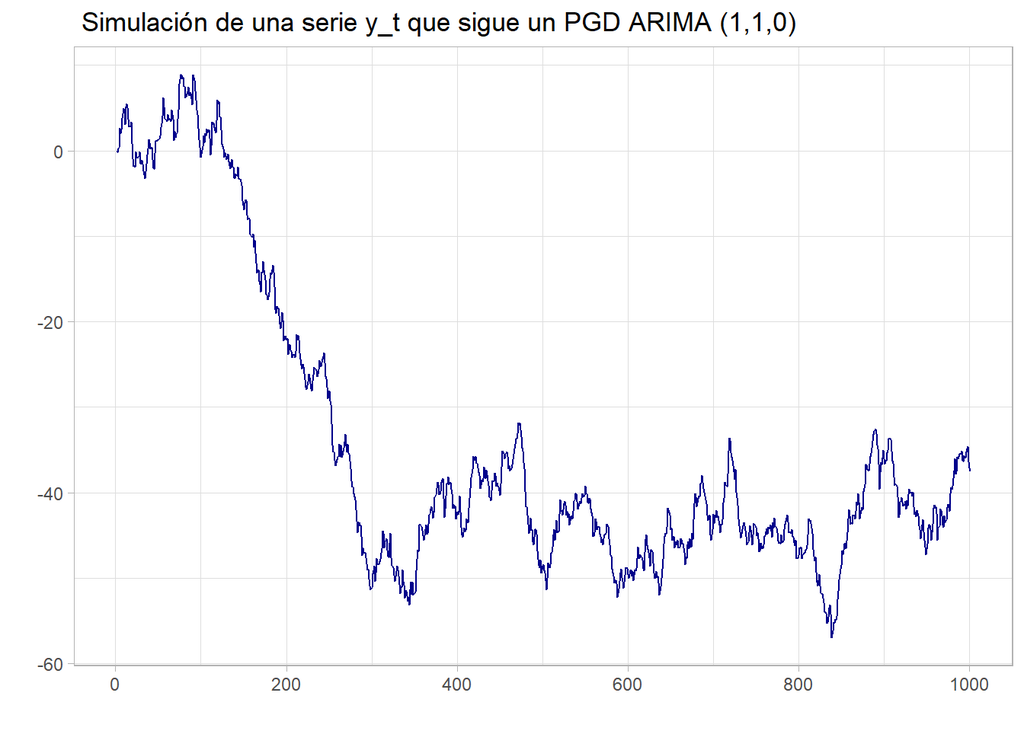

```r
x11()
autoplot(yt1n, xlab="",ylab="", main=" Simulación de una serie y_t que sigue un PGD ARIMA (1,1,0)",lty=1, lwd=0.4, col="darkblue") + theme_light()
```

Notemos que este proceso no parece tener una media constante y es altamente persistente, por lo que no satisface otras de las propiedades de un proceso estacionario que es ser débilmente dependiente.

Dado esto, observemos el comportamiento de sus gráficos de correlación.

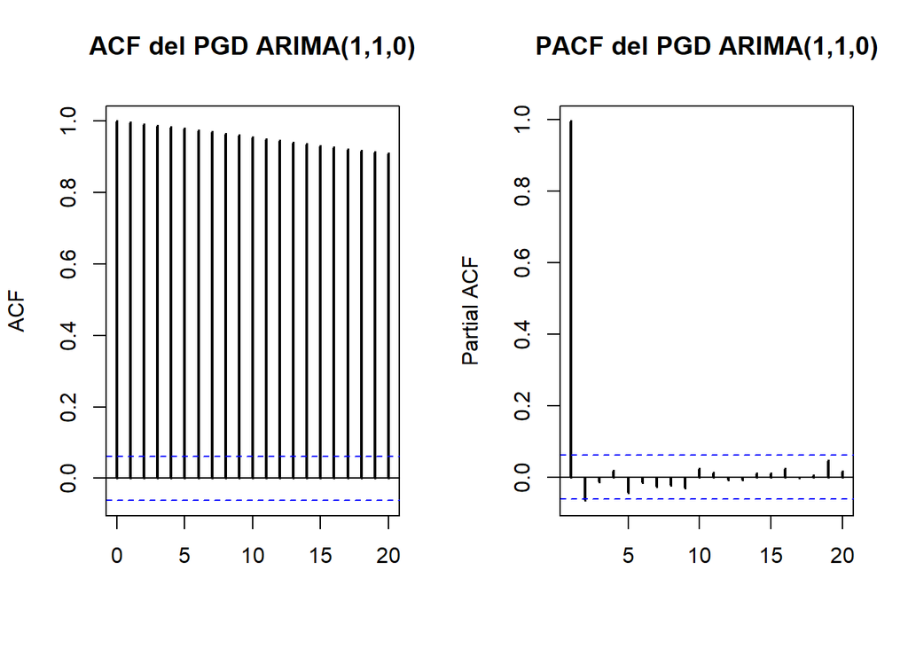

```r
x11()
lags=20
par(mfrow=c(1,2))
acf(yt1n,lag.max=lags,plot=T,lwd=2,xlab='',main='ACF del PGD ARIMA(1,1,0)')
pacf(yt1n,lag.max=lags,plot=T,lwd=2,xlab='',main='PACF del PGD ARIMA(1,1,0)')
```

Los procesos no estacionarios se caracterizar porque no hay una caída geométrica de la “ACF”. Cuándo hay un caída muy lenta de la ACF (que pareciera tener una caída “lineal” lenta), es un indicio muy fuerte de que el proces no es estacionario.

No obstante, desde ya se les reitera la importancia de complementar el análisis gráfico de una series de tiempo con análisis formal (usando pruebas formales), como los son las de pruebas de raíz unitaria, para saber si una series es estacionaria o no lo es y para conocer el orden de integración de una serie.

## 3.1 Diferenciación

Diferenciemos la serie.

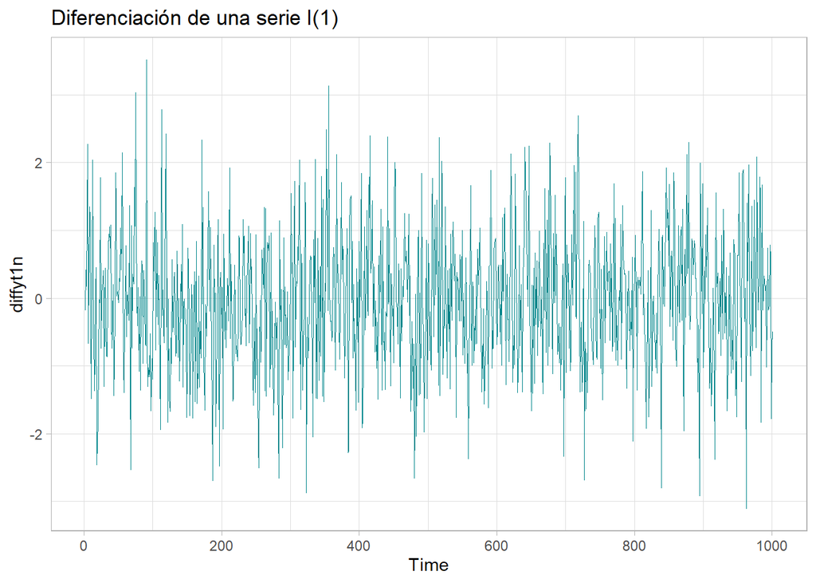

```r
diffyt1n <- diff(yt1n)
x11()
autoplot(diffyt1n, main = "Diferenciación de una serie I(1)", col="turquoise4", lty=1, lwd=0.25) + theme_light()
```

Veamos como el proceso presenta un comportamiento estacionario despues de diferenciarlo una (1) vez (Orden de integración = 1). Analicemos los correlogramas.

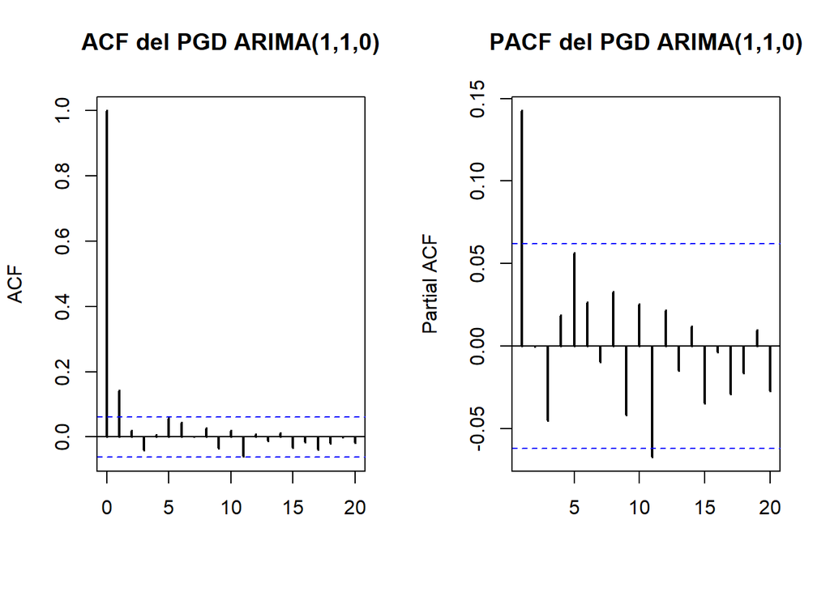

```r
x11()
lags=20
par(mfrow=c(1,2))
acf(diffyt1n,lag.max=lags,plot=T,lwd=2,xlab='',main='ACF del PGD ARIMA(1,1,0)')
pacf(diffyt1n,lag.max=lags,plot=T,lwd=2,xlab='',main='PACF del PGD ARIMA(1,1,0)')
```

Claramente, se observa que la ACF ahora cae de manera rápida y “geométrica” lo que es un indicativo de que la primera diferencia de la serie es estacionaria

# 4. Proceso AR (2) estacionario

Simulemos un proceso autorregresivo de orden 2.

```r
set.seed(2929)

yt2s = ts(arima.sim(model= list(order = c(2,0,0), ar=c(0.6,0.3)), n = obs, innov=rnorm(n = obs, mean = 0, sd = 1)))
```

Procedemos a graficarlo.

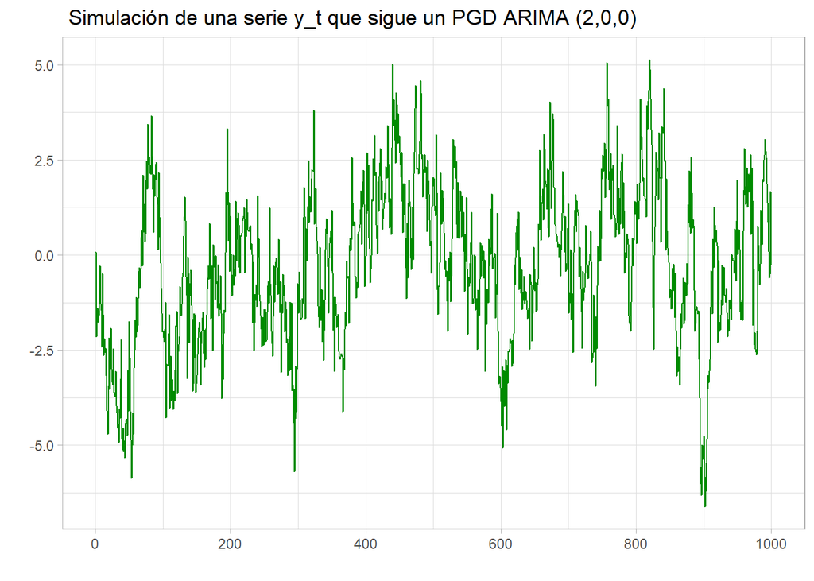

```r
x11()
autoplot(yt2s, xlab="",ylab="", main=" Simulación de una serie y_t que sigue un PGD ARIMA (2,0,0)",lty=1, lwd=0.4, col="green4") + theme_light()
```

El proceso gráficamente sigue pareciendo estacionario, pero claramente muestra una mayor persistencia a comparación del modelo AR(1). Esto se debe a que el orden mayor del AR es indicativo de que los valores presentes de la serie dependen no solo del primer sino también del segundo rezago, lo que sugiere una mayor persistencia en el proceso como lo muestra la gráfica.

Grafiquemos la FAC y FACP

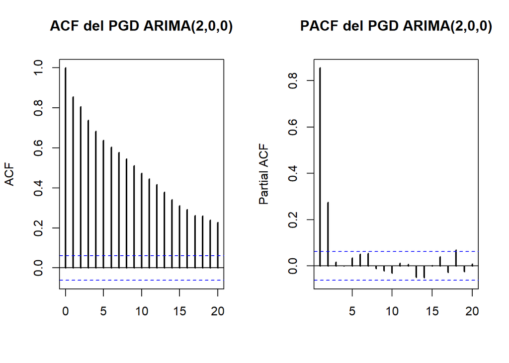

```r
x11()
lags=20
par(mfrow=c(1,2))
acf(yt2s,lag.max=lags,plot=T,lwd=2,xlab='',main='ACF del PGD ARIMA(2,0,0)')
pacf(yt2s,lag.max=lags,plot=T,lwd=2,xlab='',main='PACF del PGD ARIMA(2,0,0)')
```

Se puede ver la caída “geométrica” de la ACF característica de las series estacionarias. No obstante, se muestra que dicha caída es más lenta a comparación del proceso AR(1) estacionario, lo que es un indicativo de que un proceso AR(2) estacionario presenta mayor persistencia. Adicionalmente en el gráfico FACP vemos dos rezagos estadísticamente significativos, ya podemos ver como esta gráfica es la que determina el orden p de los procesos autorregresivos puros.

# 5. Proceso AR (2) NO estacionario

Veamos un proceso de tipo ARIMA (2,1,0).

```r
set.seed(0202) #Para que los valores de la simulación no cambien

yt2n = ts(arima.sim(model= list(order = c(2,1,0), ar=c(0.6,0.3)), n = obs, innov=rnorm(n = obs, mean = 0, sd = 1)))
```

Graficamos.

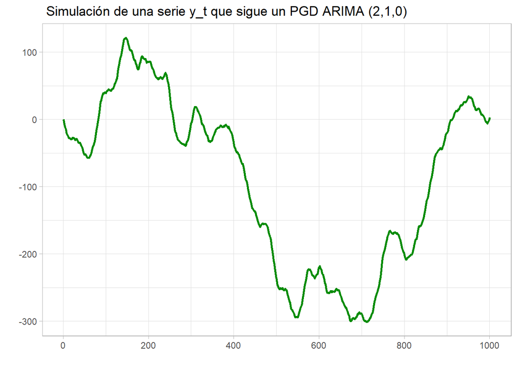

```r
x11()
autoplot(yt2n, xlab="",ylab="", main=" Simulación de una serie y_t que sigue un PGD ARIMA (2,1,0)",lty=1, lwd=0.9, col="green4") + theme_light()
```

Claramente se ve que es un proceso no estacionario, porque no hay indicios gráficamente de que la serie converga a una media en el largo plazo.

Hagamos su FAC y FACP.

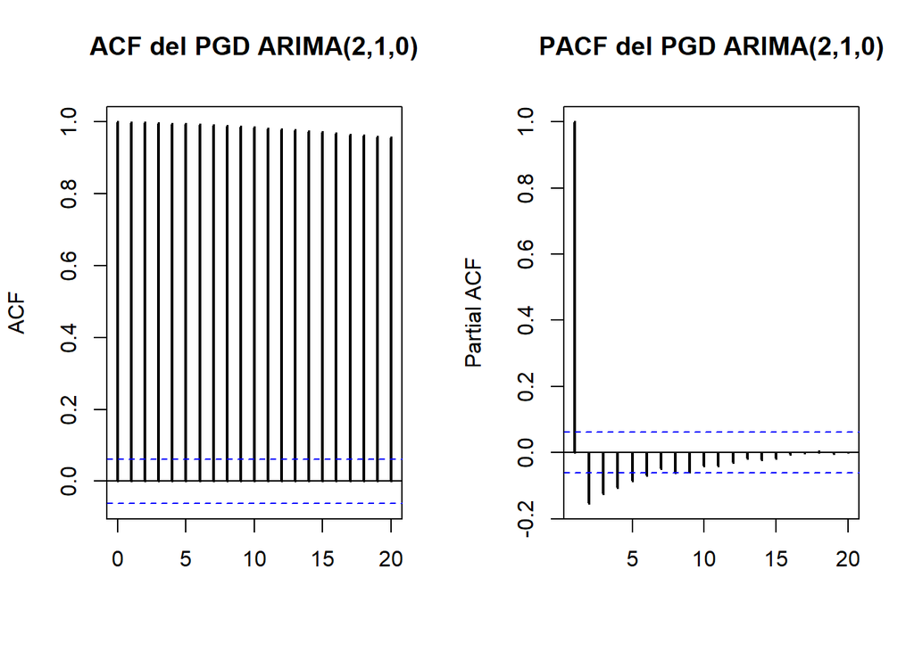

```r
x11()
lags=20
par(mfrow=c(1,2))
acf(yt2n,lag.max=lags,plot=T,lwd=2,xlab='',main='ACF del PGD ARIMA(2,1,0)')
pacf(yt2n,lag.max=lags,plot=T,lwd=2,xlab='',main='PACF del PGD ARIMA(2,1,0)')
```

Nuevamente, se observa esa caída lenta “lineal” en la ACF de la serie no estacionaria.

## 5.1 Diferenciación

Vamos a diferenciar la serie para realizar su respectivo análisis gráfico.

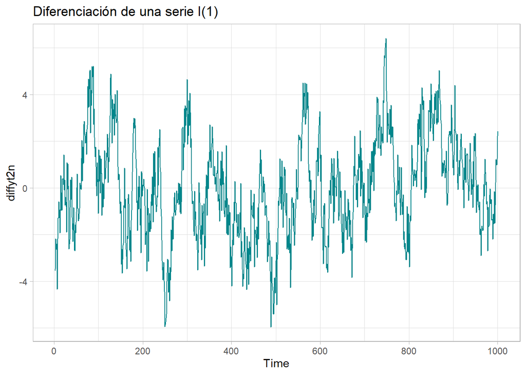

```r
diffyt2n <- diff(yt2n)
x11()
autoplot(diffyt2n, main = "Diferenciación de una serie I(1)", col="turquoise4")  + theme_light()
```

Gráficamente es posible concluir que la serie diferenciada es estacionaria. Complementemos esta conjetura con un análisis de correlación gráfico.

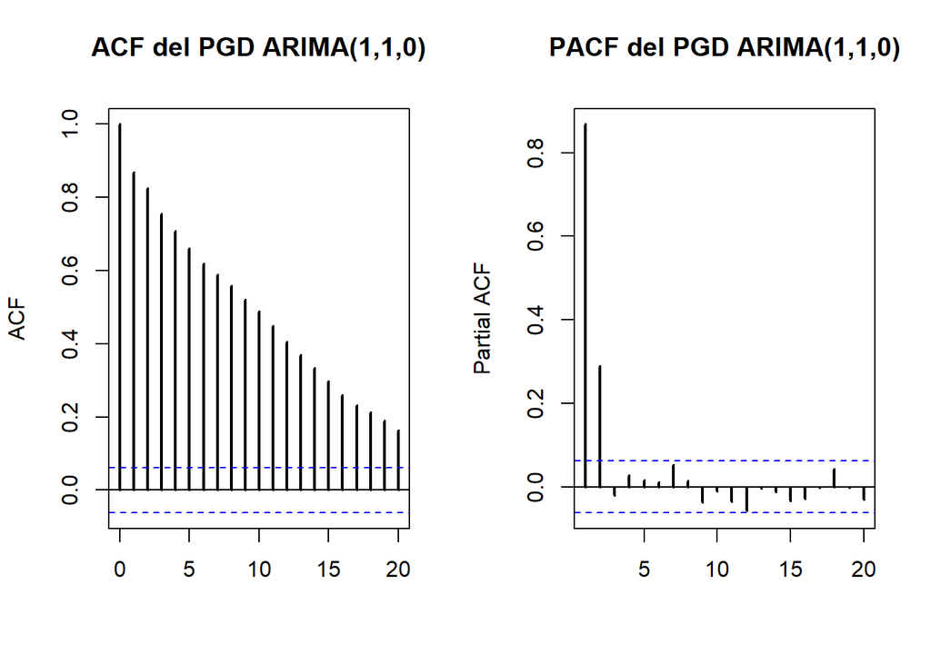

```r
x11()
lags=20
par(mfrow=c(1,2))
acf(diffyt2n,lag.max=lags,plot=T,lwd=2,xlab='',main='ACF del PGD ARIMA(1,1,0)')
pacf(diffyt2n,lag.max=lags,plot=T,lwd=2,xlab='',main='PACF del PGD ARIMA(1,1,0)')
```

Como se puede ver, ahora se observa una caída “geométrica” de la ACF que es característica de los proceso que son estacionarios.

# 6. Proceso MA (1) estacionario

Los modelos MA(q) puros generlamente son procesos menos persistente que los procesos AR(p) puros, dada su convergencia más rápida a la media de largo plazo, que es posible de mostrar analíticamente por medio del pronóstico.

```r
set.seed(2020)

yt3s = ts(arima.sim(model= list(order = c(0,0,1), ma=c(0.7)), n = obs, innov=rnorm(n = obs, mean = 0, sd = 1))) #Con este comando simulamos la serie
```

Realizamos la gráfica.

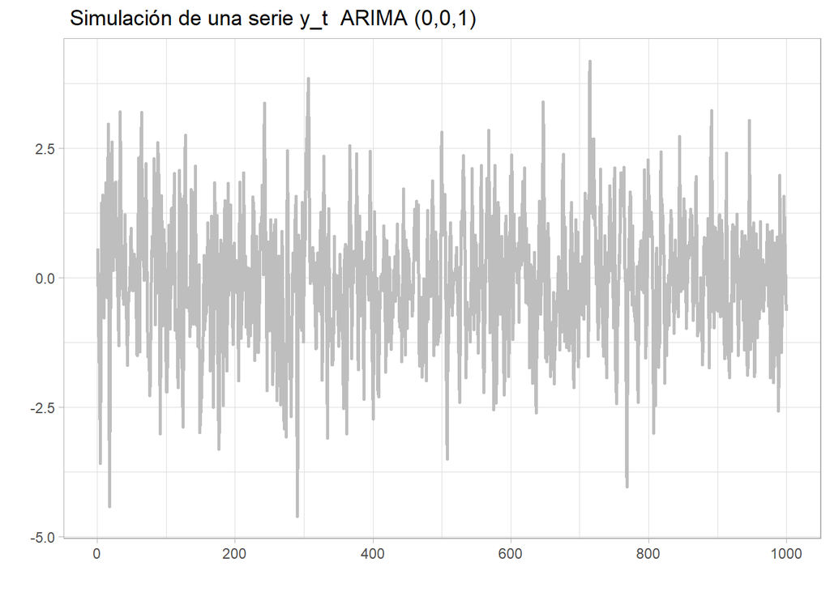

```r
autoplot(yt3s, xlab="",ylab="", main=" Simulación de una serie y_t  ARIMA (0,0,1)",lty=1, lwd=0.9, col="grey") + theme_light()
```

Claramente, la gráfica muestra un proceso que parece ser estacionario.

Realicemos sus correlogramas.

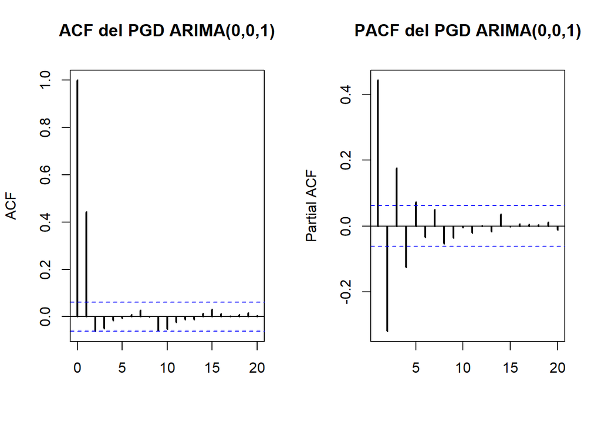

```r
lags=20
x11()
par(mfrow=c(1,2))
acf(yt3s,lag.max=lags,plot=T,lwd=2,xlab='',main='ACF del PGD ARIMA(0,0,1)')
pacf(yt3s,lag.max=lags,plot=T,lwd=2,xlab='',main='PACF del PGD ARIMA(0,0,1)')
```

El análisis acá se invierte, en tanto la FAC indica el orden “q” del proceso MA y la FACP tiene una caída geométrica oscilante que muestra que es un proceso débilmente dependiente.

Para el caso de procesos media móvil recordemos que tiene el componente estacionario inherente, es posible mostrarlo analíticamente, por lo que no generaremos procesos de media movíl puros no estacionarios.

# 7. Proceso MA (2) estacionario

Generemos el proceso.

```r
set.seed(9171) #Para que los valores de la simulación no cambien

yt4n = ts(arima.sim(model= list(order = c(0,0,2), ma=c(0.7,0.25)), n = obs, innov=rnorm(n = obs, mean = 0, sd = 1)))
```

Graficando la serie.

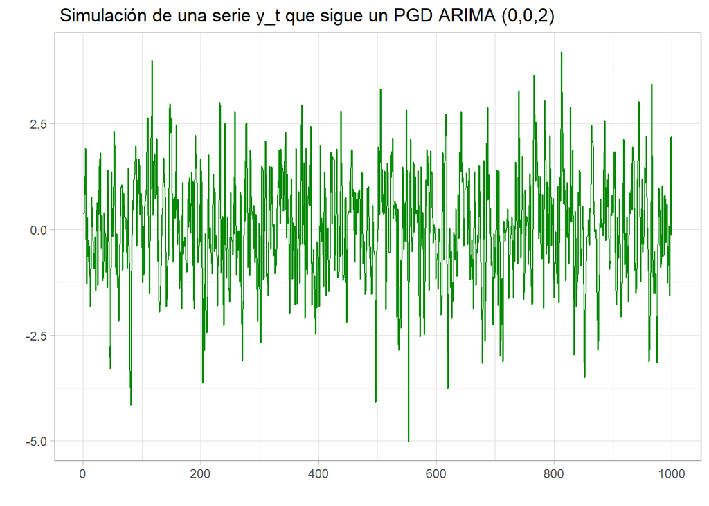

```r
x11()
autoplot(yt4n, xlab="",ylab="", main=" Simulación de una serie y_t que sigue un PGD ARIMA (0,0,2)",lty=1, lwd=0.4, col="green4") + theme_light()
```

Graficando sus correlogramas.

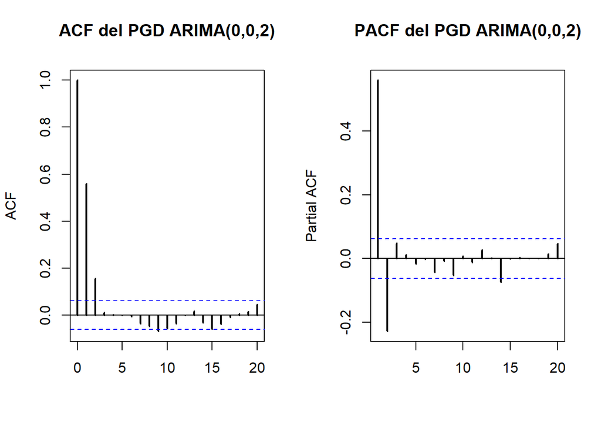

```r
x11()
par(mfrow=c(1,2))
acf(yt4n,lag.max=lags,plot=T,lwd=2,xlab='',main='ACF del PGD ARIMA(0,0,2)')
pacf(yt4n,lag.max=lags,plot=T,lwd=2,xlab='',main='PACF del PGD ARIMA(0,0,2)')
```

Nuevamente, dado el análisis que se invierte para este caso, podemos observar dos rezagos significativos para la FAC y una convergencia geométrica hacia cero en la FACP

# 8. Proceso ARMA (1,1) estacionario

Los modelos ARMA(p, q) son convenientes en la medida que permiten representar una amplia cantidad de procesos estacionarios de manera más parsimoniosa (i.e. con muy pocos coeficientes). De este forma, en lugar de representar un proceso con muchos rezagos, se puede encontrar una representación más parsimoniosa del proceso AR(p,q) que tenga menos parámetros.

Es así que la componente de media móvil en un ARMA ayuda a ajustar mejor el modelo y reduce la necesidad de incluir tantos rezagos autoregresivos para representar el proceso que se está estudiando. Finalmente, recuerden que a la hora de trabajar con series de tiempo es conveniente trabajar modelos parsimoniosos en la medida que le dan mayor flexibilidad al modelo (al menos en el pronóstico), consumen menos grados de libertad y son importantes a la hora de considerar la confiabilidad de un modelo.

Generemos el proceso.

```r
set.seed(220422) #Para que los valores de la simulación no cambien
yt5s = ts(arima.sim(model= list(order = c(1,0,1), ar=c(0.7),ma=c(0.3)), n = 1000, innov=rnorm(n = obs, mean = 0, sd = 1)))
```

Graficamos el proceso.

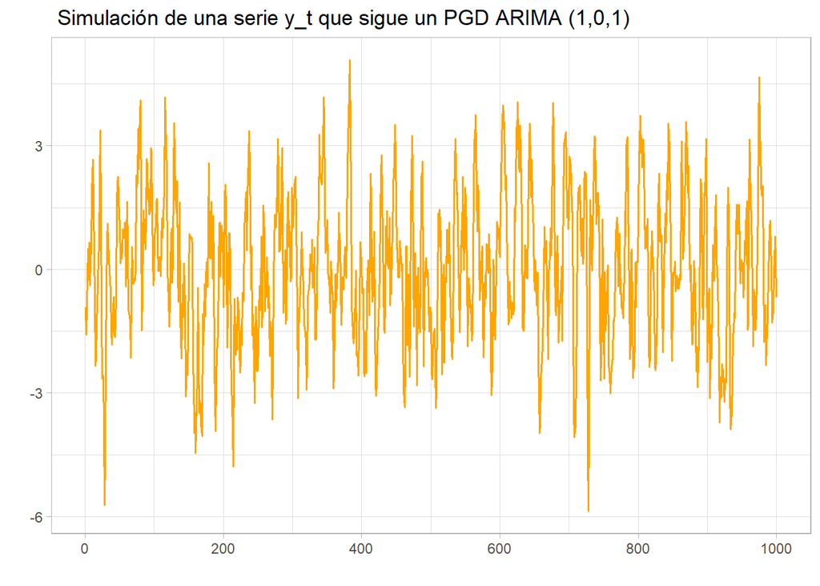

```r
x11()
autoplot(yt5s, xlab="",ylab="", main=" Simulación de una serie y_t que sigue un PGD ARIMA (1,0,1)",lty=1, lwd=0.7, col="orange") + theme_light()
```

Grafiquemos sus correlogramas.

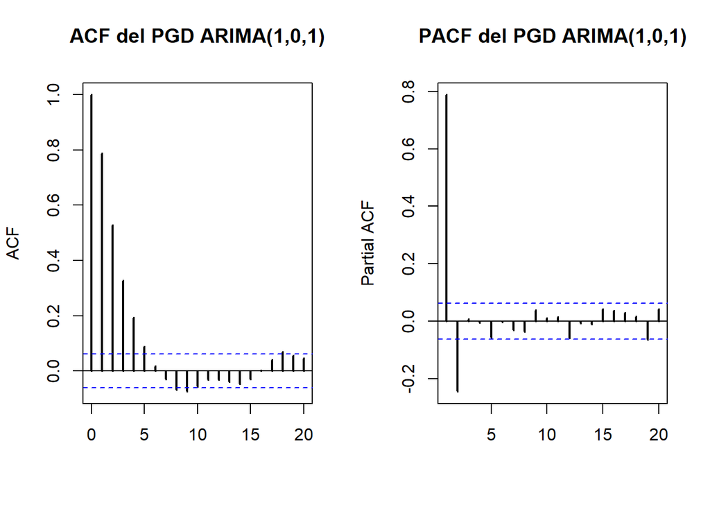

```r
lags=20
x11()
par(mfrow=c(1,2))
acf(yt5s,lag.max=lags,plot=T,lwd=2,xlab='',main='ACF del PGD ARIMA(1,0,1)')
pacf(yt5s,lag.max=lags,plot=T,lwd=2,xlab='',main='PACF del PGD ARIMA(1,0,1)')
```

Para un proceso ARMA(p,q) es más complejo el análisis de ACF y PACF. Ésto se debe a que a diferencia de una AR puro o un MA puro puede que las ACF y la PAFC del ARMA(p,q) no se corten abruptamente como si pasa en los procesos “puros”. No obstante, como ya se mencionó, un proceso ARMA(p, q) permite mayor flexibilidad en el modelamiento y además generá modelos más parsimoniosos a comparación de los modelos “puros”.

Se destaca además, que respecto a la ACF se observa la típica caída “geométrica” que uno esperaría observar de una serie estacionaria.

# 9. Proceso ARIMA (1,1,1)

Generemos la simulación.

```r
set.seed(81711) #Para que los valores de la simulación no cambien

yt5n = ts(arima.sim(model= list(order = c(1,1,1),ar=c(0.6), ma=c(0.7)), n = obs, innov=rnorm(n = obs, mean = 0, sd = 1)))
```

No podemos esperar de este proceso una media ni varianza constante al largo plazo.

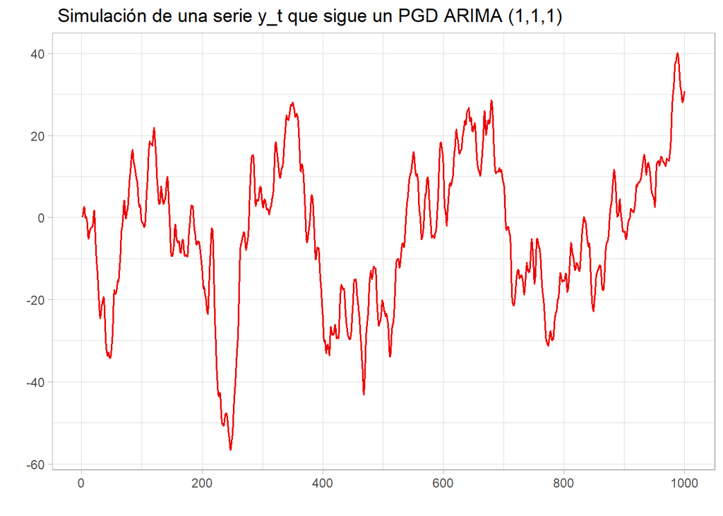

```r
x11()
autoplot(yt5n, xlab="",ylab="", main=" Simulación de una serie y_t que sigue un PGD ARIMA (1,1,1)",lty=1, lwd=0.7, col="red2") + theme_light()
```

Además, grafiquemos los correlogramas.

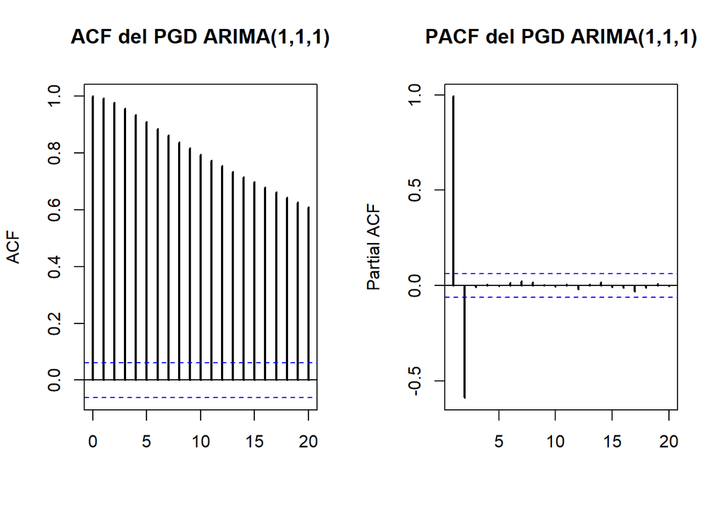

```r
lags=20
x11()
par(mfrow=c(1,2))
acf(yt5n,lag.max=lags,plot=T,lwd=2,xlab='',main='ACF del PGD ARIMA(1,1,1)')
pacf(yt5n,lag.max=lags,plot=T,lwd=2,xlab='',main='PACF del PGD ARIMA(1,1,1)')
```

Se observa la típica caída “lineal” lenta que uno esperaría ver en una serie no estacionaria.

## 9.1 Diferenciación

Como sabemos, diferenciemos y grafiquemos la serie.

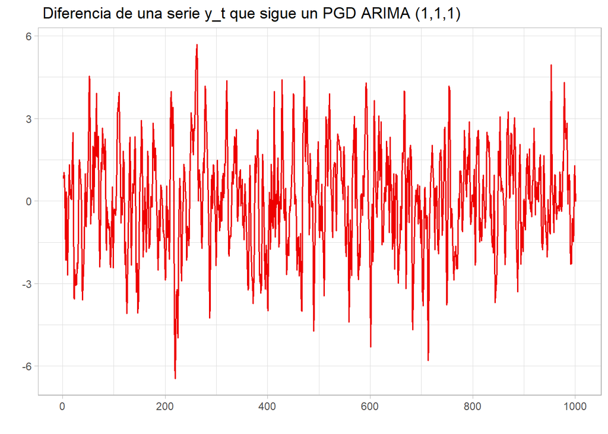

```r
dif_yt5n <- diff(yt5n)

x11()
autoplot(dif_yt5n, xlab="",ylab="", main=" Diferencia de una serie y_t que sigue un PGD ARIMA (1,1,1)",lty=1, lwd=0.7, col="red2") + theme_light()
```

Finalmente veamos sus correlogramas.

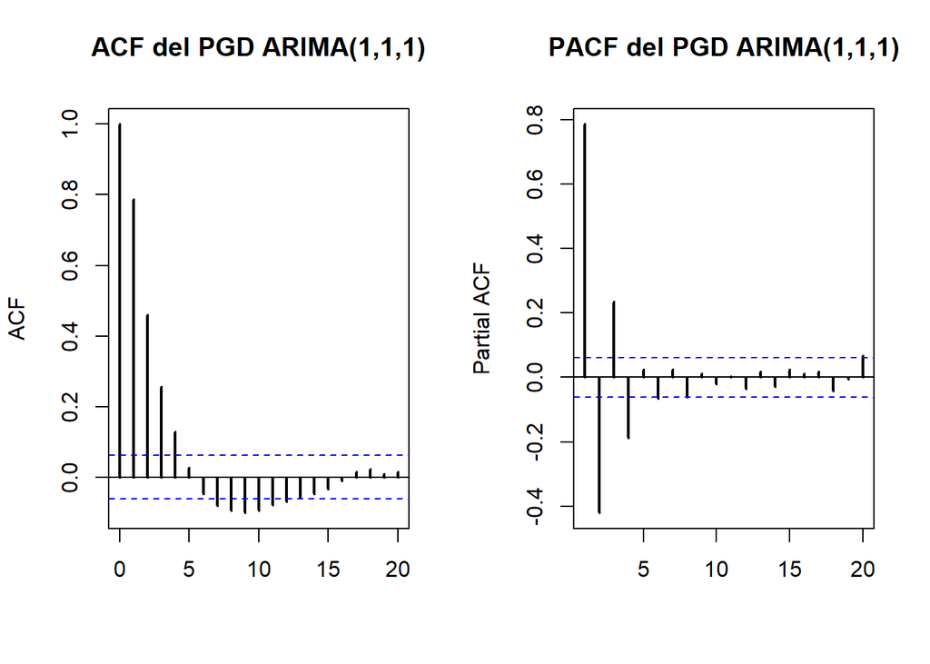

```r
x11()
par(mfrow=c(1,2))
acf(dif_yt5n,lag.max=lags,plot=T,lwd=2,xlab='',main='ACF del PGD ARIMA(1,1,1)')
pacf(dif_yt5n,lag.max=lags,plot=T,lwd=2,xlab='',main='PACF del PGD ARIMA(1,1,1)')
```

Como se esperaba, es posible ver la tipica convergencia a cero en ambas gráficas dada la presencia tanto de componente MA como de AR.